# Clasificación de imagenes de radiografias de tórax entre normales y con derrame

Machine Learning - PEC 1

Jorge Vallejo Ortega

4 de abril, 2020

# Algoritmo k-NN

El algoritmo de los k vecinos más próximos (*k-nearest neighbours*) es un algoritmo de aprendizaje automático (*machine learning*) que se utiliza para clasificar observaciones, según si sus características las hacen más parecidas a uno u otro grupo ya establecidos.

En una primera fase de ‘entrenamiento’, una colección de observaciones ya clasificadas se distribuyen en un espacio *n*-dimensional. Cada dimensión corresponde a una de las variables medidas en las observaciones. Las nuevas observaciones, las cuales queremos clasificar, se distribuyen a su vez en ese espacio *n*-dimensional; y se clasifican dentro de los grupos a los que pertenezcan aquellas otras observaciones, ya clasificadas, de las que más cerca se encuentren. El número de observaciones conocidas que tenemos en cuenta para clasificar las observaciones nuevas, es ése número *k*.

## Fortalezas y debilidades del algoritmo

| Fortalezas | Debilidades |
| --- | --- |
| *Simple y efectivo | * No produce un modelo, limitando la habilidad para entender cómo las características se relacionan con la clasificación |
| * No hace asunciones acerca de la distribución subyacente de los datos | * Requiere seleccionar una *k* adecuada |
| * Fase de entrenamiento rápida | * Fase de clasificación lenta |
|  | * Se requiere procesado adicional para características nominales y datos incompletos |

# Pre-procesado de datos

Las imágenes a clasificar deberán estar en una carpeta llamada “dataset”, en el mismo directorio que el código que vamos a correr.

```r
dir.create("./results", showWarnings = FALSE)

if (! dir.exists("./dataset")) {
  stop("El directorio ./dataset no existe")
}

# DONE Si datasets existe
#    si contiene datos
#        Continúa con el script
#    else: Aviso (La carpeta datasets no contiene datos)
# DONE Else: la carpeta datasets no existe
```

```r
library('OpenImageR')

image_tovector <- function(x){
# Create filepath
filepath <- paste("./dataset", sep='/',
                  paste(as.vector(x), collapse = '/'))
#print(filepath)
# Read image
image <- readImage(filepath)
# Convert to greyscale
image_grey <- rgb_2gray(image)
# Resize to 64x64
image_resized <- resizeImage(image_grey, 64, 64)
# Transform from matrix to vector
return(as.vector(image_resized))
}

## TODO ## Incluir en el informe ejemplos de imagenes antes y después del preprocesado (función imageShow()).
```

```r
directories <- list.dirs("./dataset", full.names = FALSE, recursive = FALSE)
filenames <- as.data.frame(
  sapply(directories,
                    function (x){return(
                      list.files(paste0("./dataset/", x)))}))

# From wide to long format
filenames <- reshape(filenames,
                      direction="long",
                      varying = c("effusion", "normal"),
                      v.names="Filename",
                      timevar="cat",
                      times = c("effusion", "normal")
                      )
row.names(filenames) <- NULL
filenames$id <- NULL
#filenames$Condition <- as.factor(filenames$Condition)
filenames$Filename <- as.character(filenames$Filename)
```

```r
#Check if the file already exists
if(file.exists("image_vectors.RData")){
  load("image_vectors.RData")
}else{
# Matrix of vectorized images
image_vectors <- apply(filenames, 1, image_tovector)
save(image_vectors, file = "image_vectors.RData")
}
# This if-else block is to avoid re-calculating
# the object every time I want to try the code.
# I have just have care to remove the .RData file
# if I want to re-calculate it.

## TODO Keep the file names as col names

# Transpose to have images as observations
image_vectors <- as.data.frame(t(image_vectors))
```

```r
## How to check if each row if really an x-ray image:
test_row <- function(x){
# Extract one row of the dataframe and store as a numeric vector
 test <- as.numeric(image_vectors[x,])
# Transform vector into matrix
 test <- matrix(test, ncol=64)
# Check if you obtain an x-ray image
 imageShow(test)
}
```

```r
image_vectors <- cbind(filenames, image_vectors)
# Change cat variable to factors
image_vectors$cat <- as.factor(image_vectors$cat)
levels(image_vectors$cat) <- c("e", "n")
```

```r
if( ! file.exists("./results/RX_Torax_4097.csv")){
  write.csv2(image_vectors,
           file="./results/RX_Torax_4097.csv",
           row.names = FALSE)
}

# Structured in that way to avoid writing the file
# each time that I want to test the script,
# especially if I just want to test knitting
```

### Lectura de datos

```r
image_vectors <- read.csv2("./results/RX_Torax_4097.csv")
```

### Estructura de los datos

```r
observaciones <- nrow(image_vectors)
variables <- ncol(image_vectors)-2
```

El set de datos examinado está compuesto por 1000 observaciones, de las cuales se han tomado 4096 variables, y están divididas en 2 clases (effusion, normal) that are codified as e, n.

La distribución de cada clase es la siguiente:

```r
kable(table(image_vectors$cat),
      col.names = c("Clase", "Frecuencia"),
      align = c('r','l'))
```

| Clase | Frecuencia |
| --- | --- |
| e | 500 |
| n | 500 |

### Histograma de medias

```r
image_vectors_normal <- image_vectors[image_vectors$cat == 'n',]
image_vectors_effusion <- image_vectors[image_vectors$cat == 'e',]

media_normal <- apply(image_vectors_normal[,3:ncol(image_vectors_normal)], 2, mean)
media_effusion <- apply(image_vectors_effusion[,3:ncol(image_vectors_effusion)], 2, mean)
```

```r
sd_normal <- apply(image_vectors_normal[,3:ncol(image_vectors_normal)], 2, sd)
sd_effusion <- apply(image_vectors_effusion[,3:ncol(image_vectors_effusion)], 2, sd)
```

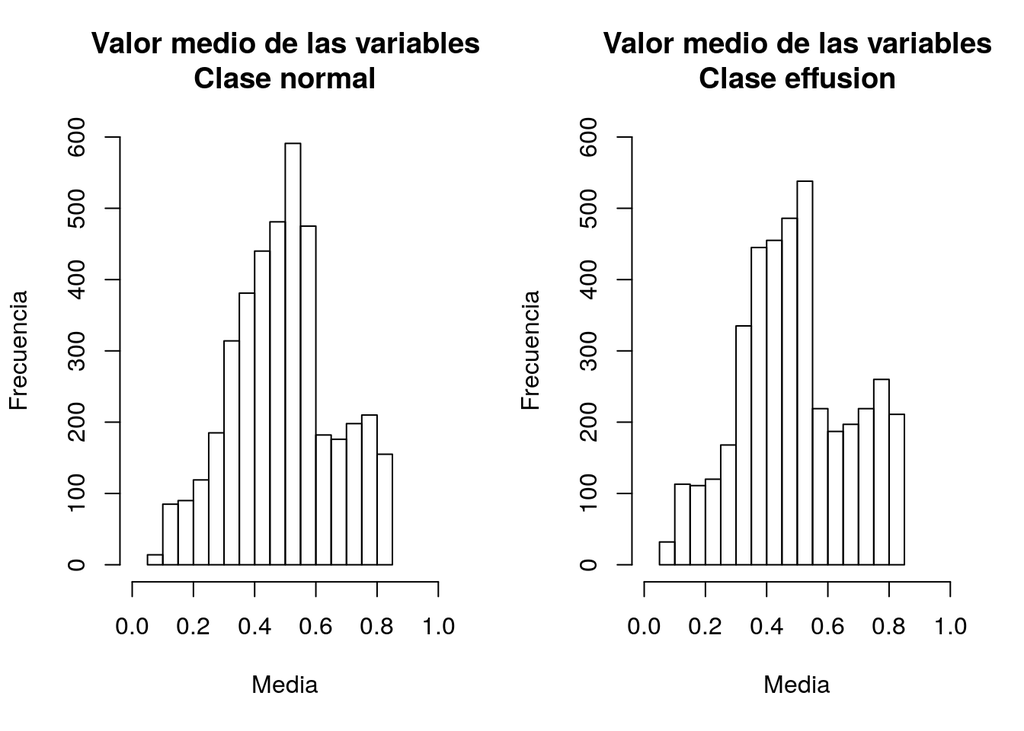

```r
par(mfrow= c(1,2))
hist(media_normal,
     main="Valor medio de las variables\nClase normal",
     ylab = "Frecuencia",
     xlab = "Media",
     xlim = c(0,1),
     ylim = c(0, max_y))

hist(media_effusion,
     main="Valor medio de las variables\nClase effusion",
     ylab = "Frecuencia",
     xlab = "Media",
     xlim = c(0,1),
     ylim = c(0, max_y))
```

Los valores medios de las variables en la clase “normal” parecen estar más concentrados en el centro de la distribución, mientras que en la clase “effusion” la distribución es más achatada. Esto podría significar que las imágenes de la clase “effusion” presentan áreas más claras y más oscuras que las imágenes de la clase “normal”.

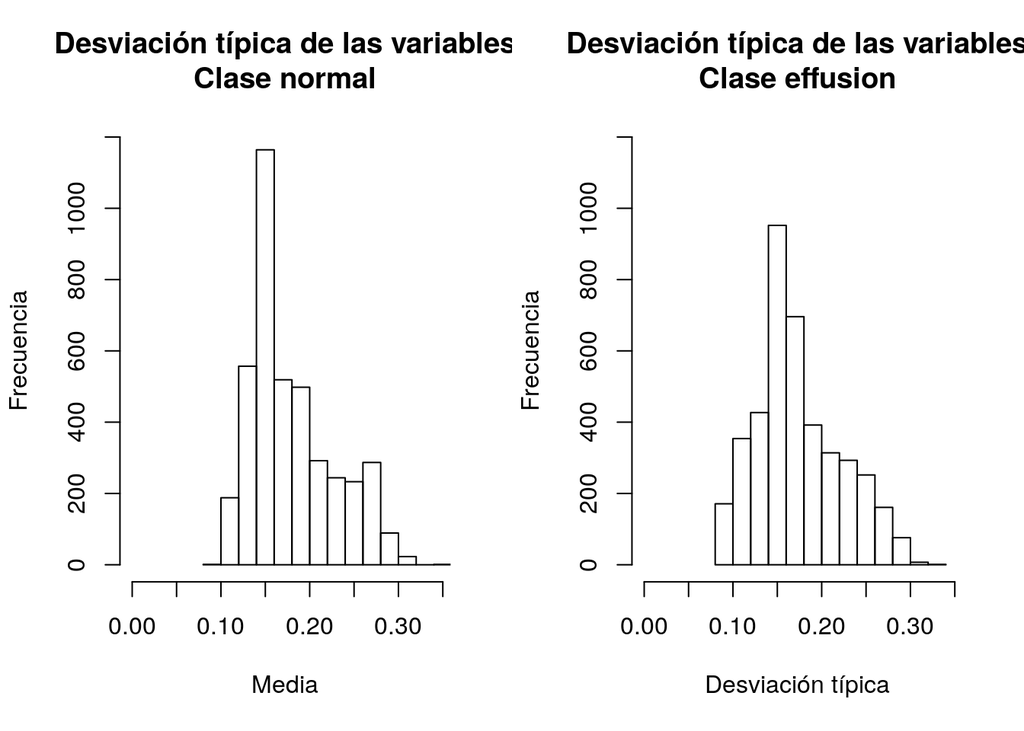

```r
par(mfrow= c(1,2))
hist(sd_normal,
     main="Desviación típica de las variables\nClase normal",
     ylab = "Frecuencia",
     xlab = "Media",
     xlim = c(0,max_xe),
     ylim = c(0, max_ye))

hist(sd_effusion,
     main="Desviación típica de las variables\nClase effusion",
     ylab = "Frecuencia",
     xlab = "Desviación típica",
     xlim = c(0,max_xe),
     ylim = c(0, max_ye))
```

## Contraste de valores medios (t-test)

```r
# Código adaptado de
# https://stackoverflow.com/questions/13790611/apply-t-test-on-many-columns-in-a-dataframe-split-by-factor
variables_t_test <- t(sapply(image_vectors[c(-1,-2)], function(x)
  unlist(t.test(x~image_vectors$cat)[c("estimate", "p.value")])))
```

```r
variables_t_test_adjusted <- as.data.frame(variables_t_test)
variables_t_test_adjusted[,3] <- p.adjust(variables_t_test_adjusted[,3])
# Ordenar los valores de menor a mayor
ordered_p_values <- variables_t_test_adjusted[order(variables_t_test[,3]),]
# Añadir columna con diferencia de medias
ordered_p_values[, "diferencia"] <- ordered_p_values[,1] - ordered_p_values[,2]
# Preparar para mostrar como tabla
library(xtable)
xtable(ordered_p_values[1:25,-c(1,2)],
       caption = "Tabla con los 25 descriptores de menor p-valor",
       digits = 4,
       display=c("s", "e", "fg"))
```

[output not shown]

## Implementación del algoritmo knn

Dividimos el set de datos, al azar, en un set de entrenamiento (67% de las observaciones) y un set de prueba (33% de los datos).

```r
set.seed(123)
# Reordered row numbers
observaciones <- nrow(image_vectors)
shuffled_rows <- sample(observaciones)
training_rows <- shuffled_rows[1:(observaciones*0.67)]
test_rows <- shuffled_rows[((observaciones*0.67)+1):observaciones]
# Remember to use only numeric variables
image_vectors_training <- image_vectors[training_rows, 3:ncol(image_vectors)]
image_vectors_test <- image_vectors[test_rows, 3:ncol(image_vectors)]

# Category labels
image_vectors_train_labels <- image_vectors_training[, 1]
image_vectors_test_labels <- image_vectors_test[, 1]
```

## Evalúa diferentes valores de k

```r
library('class')
library('gmodels')

k <- c(3, 5, 7, 11, 23, 45, 67)

evaluator <- function (x){
  image_vectors_test_pred <- knn(train = image_vectors_training,
                               test = image_vectors_test,
                               cl = image_vectors_train_labels,
                               k=x)
  Results_table <- prop.table(
    table(image_vectors_test_labels,
          image_vectors_test_pred))
  return(c(x, Results_table[3], Results_table[2]))
}

#Check if the file already exists
if(file.exists("./results/evaluated_k.RData")){
  load("./results/evaluated_k.RData")
}else{
# Evaluate the different k values
  evaluated_k <- sapply(k, evaluator)
  save(evaluated_k, file="./results/evaluated_k.RData")
}
# This if-else block is to avoid re-calculating
# the object every time I want to try the code.
# I have just have care to remove the .RData file
# if I want to re-calculate it.


# Format results as a data frame
dtevaluated_k <- as.data.frame(t(evaluated_k))
# Add column for total errors of classifying
dtevaluated_k[,4] <- (dtevaluated_k[,2] + dtevaluated_k[,3])
# Add column names
colnames(dtevaluated_k) <- c("k","False Negatives", "False Positives", "Total Error")
# Format as percentages
dtevaluated_k[,2:4] <- round(dtevaluated_k[,2:4], 3)*100
dtevaluated_k[,2:4] <- mapply(paste0, dtevaluated_k[,2:4], "%")

# Print table
knitr::kable(dtevaluated_k,
             align = c("c","c","c","c"))
```

| k | False Negatives | False Positives | Total Error |
| --- | --- | --- | --- |
| 3 | 0.3% | 2.4% | 2.7% |
| 5 | 0.6% | 1.8% | 2.4% |
| 7 | 0% | 0.9% | 0.9% |
| 11 | 0% | 0.9% | 0.9% |
| 23 | 0.3% | 0.9% | 1.2% |
| 45 | 0.9% | 0.9% | 1.8% |
| 67 | 0.9% | 1.5% | 2.4% |